# Chapter 8

## Conceptual

### Excercise 1

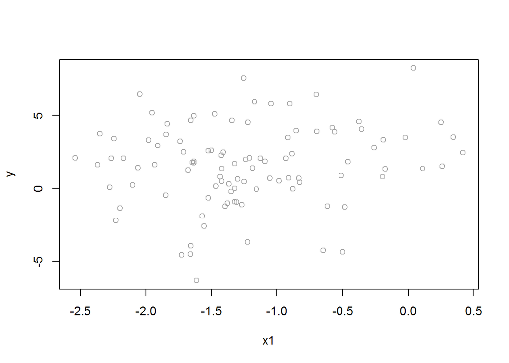

```r
set.seed(1)
error = 0.7*rnorm(100)
x1 = rnorm(100, mean = -1.2, sd = 0.7)
x2 = rnorm(100, mean = 0.5, sd = 1.5)
beta0 = 1.6; beta1 = 0.8; beta2 = 1.7
y = beta0 + beta1*x1 + beta2*x2 + error
plot(x1, y, col = "darkgrey")
```

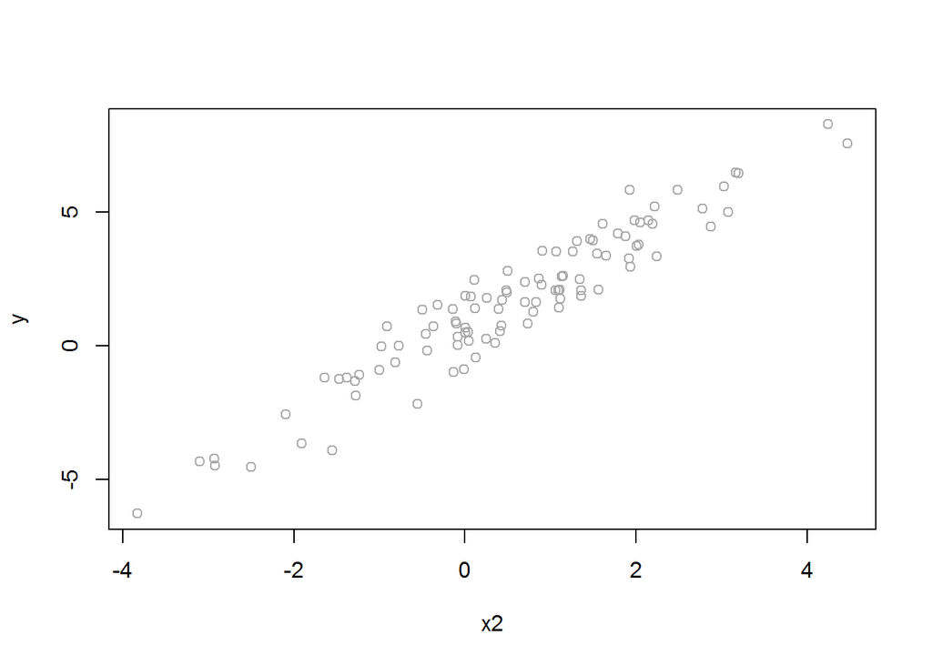

```r
plot(x2, y, col = "darkgrey")
```

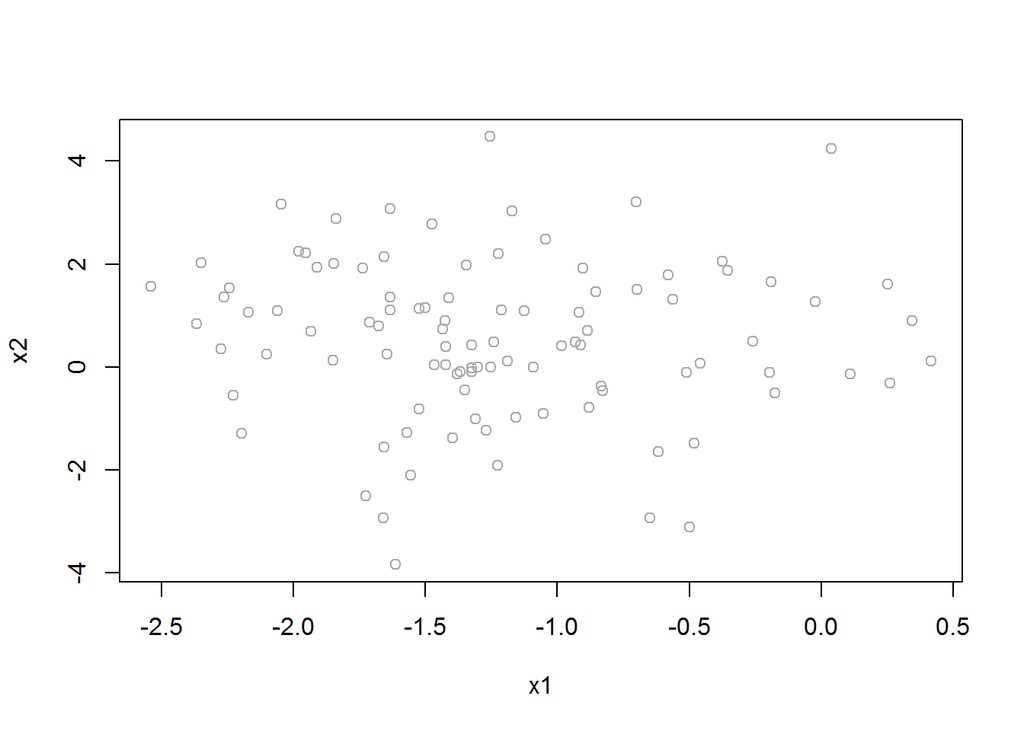

```r
plot(x1, x2, col = "darkgrey")
```

```r
library(tree)
sim.tree = tree(y~., data = data.frame(x1 = x1, x2 = x2, y = y))
summary(sim.tree)
```

```
##
## Regression tree:
## tree(formula = y ~ ., data = data.frame(x1 = x1, x2 = x2, y = y))
## Number of terminal nodes:  7
## Residual mean deviance:  0.738 = 68.63 / 93
## Distribution of residuals:
##      Min.   1st Qu.    Median      Mean   3rd Qu.      Max.
## -2.371000 -0.466600 -0.001546  0.000000  0.490600  2.715000
```

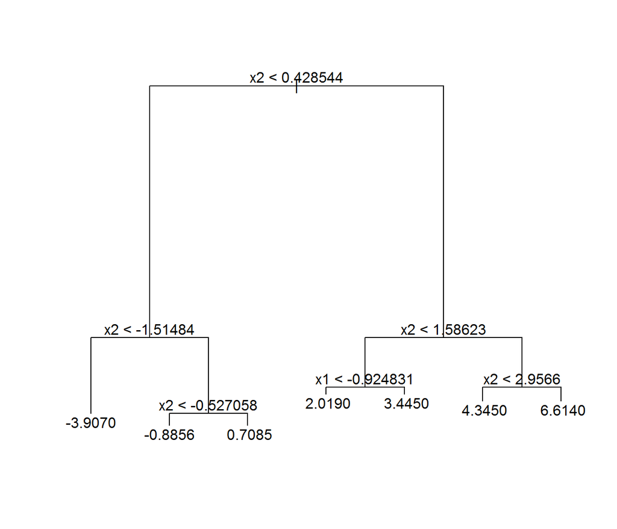

```r
plot(sim.tree)
text(sim.tree, pretty = 0)
```

```r
sim.tree
```

```
## node), split, n, deviance, yval
##       * denotes terminal node
##
##  1) root 100 748.300  1.6210
##    2) x2 < 0.428544 47 187.000 -0.5484
##      4) x2 < -1.51484 9  15.830 -3.9070 *
##      5) x2 > -1.51484 38  45.610  0.2470
##       10) x2 < -0.527058 11   7.299 -0.8856 *
##       11) x2 > -0.527058 27  18.450  0.7085 *
##    3) x2 > 0.428544 53 144.100  3.5440
##      6) x2 < 1.58623 29  20.170  2.4120
##       12) x1 < -0.924831 21   6.062  2.0190 *
##       13) x1 > -0.924831 8   2.332  3.4450 *
##      7) x2 > 1.58623 24  41.840  4.9120
##       14) x2 < 2.9566 18  11.950  4.3450 *
##       15) x2 > 2.9566 6   6.703  6.6140 *
```

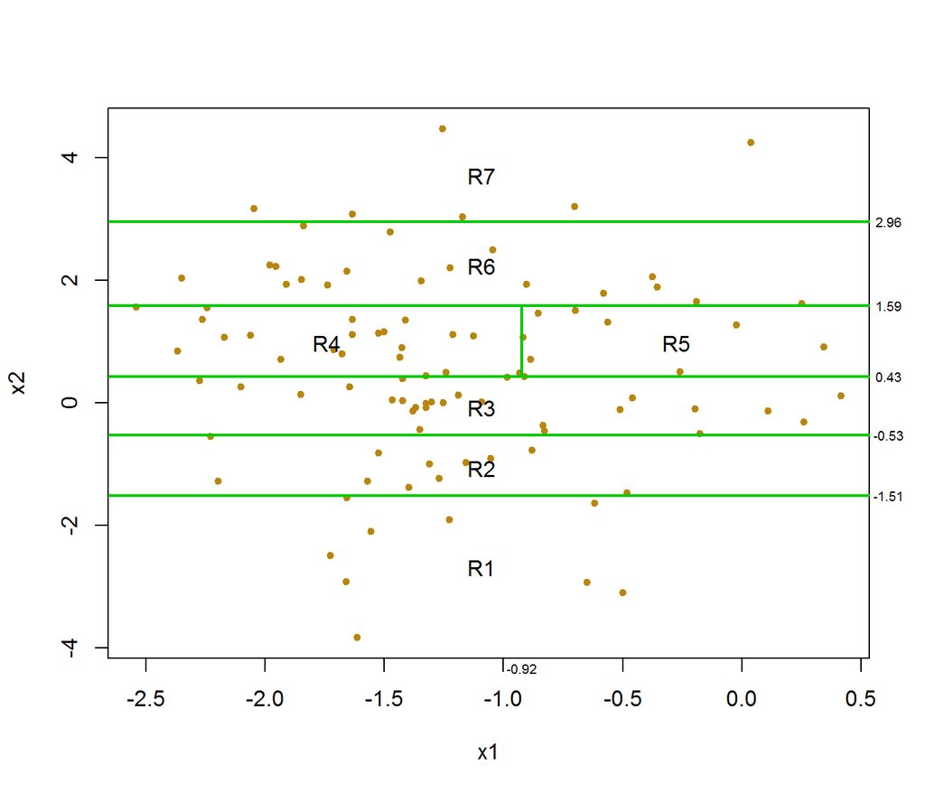

```r
plot(x1, x2, col = "darkgoldenrod", pch = 20)
abline(0.428544, 0, col = "green3", lwd = 2)
abline(-1.51484, 0, col = "green3", lwd = 2)
abline(-0.527058, 0, col = "green3", lwd = 2)
abline(1.58623, 0, col = "green3", lwd = 2)
text(x = mean(seq(min(x1), max(x1), 0.1)), y = mean(seq(min(x2), -1.51484, 0.1)), label = "R1")
text(x = mean(seq(min(x1), max(x1), 0.1)), y = mean(seq(-1.51484, -0.527058, 0.1)), label = "R2")
text(x = mean(seq(min(x1), max(x1), 0.1)), y = mean(seq(-0.527058, 0.428544, 0.1)), label = "R3")
segments(-0.924831, 0.428544, -0.924831, 1.58623, col = "green3", lwd = 2)
text(x = mean(seq(min(x1), -0.924831, 0.1)), y = mean(seq(0.428544, 1.58623, 0.1)), label = "R4")
text(x = mean(seq(-0.924831, max(x1), 0.1)), y = mean(seq(0.428544, 1.58623, 0.1)), label = "R5")
abline(2.9566, 0, col = "green3", lwd = 2)
text(x = mean(seq(min(x1), max(x1), 0.1)), y = mean(seq(1.58623, 2.9566, 0.1)), label = "R6")
text(x = mean(seq(min(x1), max(x1), 0.1)), y = mean(seq(2.9566, max(x2), 0.1)), label = "R7")
par(xpd=TRUE)
text(x = max(x1)+0.2, y = -1.51484, label = "-1.51", cex = 0.6)
text(x = max(x1)+0.2, y = -0.527058, label = "-0.53", cex = 0.6)
text(x = max(x1)+0.2, y = 0.428544, label = "0.43", cex = 0.6)
text(x = max(x1)+0.2, y = 1.58623, label = "1.59", cex = 0.6)
text(x = max(x1)+0.2, y = 2.9566, label = "2.96", cex = 0.6)
text(x = -0.924831, y = min(x2)-0.5, label = "-0.92", cex = 0.6)
```

### Excercise 2

Boosting using stump is essetianlly equivalent to the additive model: for every tree generated, $\hat f ^b(x)$ is fit with $d = 1$ split to the training data $X$, which amounts to single-variable linear model $\hat f_j(x)$. For each of the trees $b = 1,2,...,B$, equivalently, there are $B$ linear models generated.

Finally, the output of boosting is represented by $\hat f(x) = \sum\limits_{b = 1}^B {\lambda {{\hat f}^b}(x)}$ , which can be treated as an additive model weighted by $\lambda$, i.e. $\hat f(x) = \lambda \sum\limits_{j = 1}^B {{{\hat f}_j}(x)}$

### Excercise 3

Classification error: $E = 1 - \mathop {\max }\limits_k ({\hat p_{mk}})$

Gini index: $G = \sum\limits_{k = 1}^K {{{\hat p}_{mk}}(1 - {{\hat p}_{mk}})}$ For two-class problem, it becomes $G = {{\hat p}_{m1}}(1 - {{\hat p}_{m1}}) + {{\hat p}_{m2}}(1 - {{\hat p}_{m2}})$ Substituting ${{\hat p}_{m2}} = 1 - {{\hat p}_{m1}}$, therefore, we have: $G = 2{{\hat p}_{m1}}(1 - {{\hat p}_{m1}})$

Cross entropy: $D = - \sum\limits_{k = 1}^K {{{\hat p}_{mk}}\log {{\hat p}_{mk}}}$ For two-class problem, it becomes $D = - {{\hat p}_{m1}}\log {{\hat p}_{m1}} - {{\hat p}_{m2}}\log {{\hat p}_{m2}}$

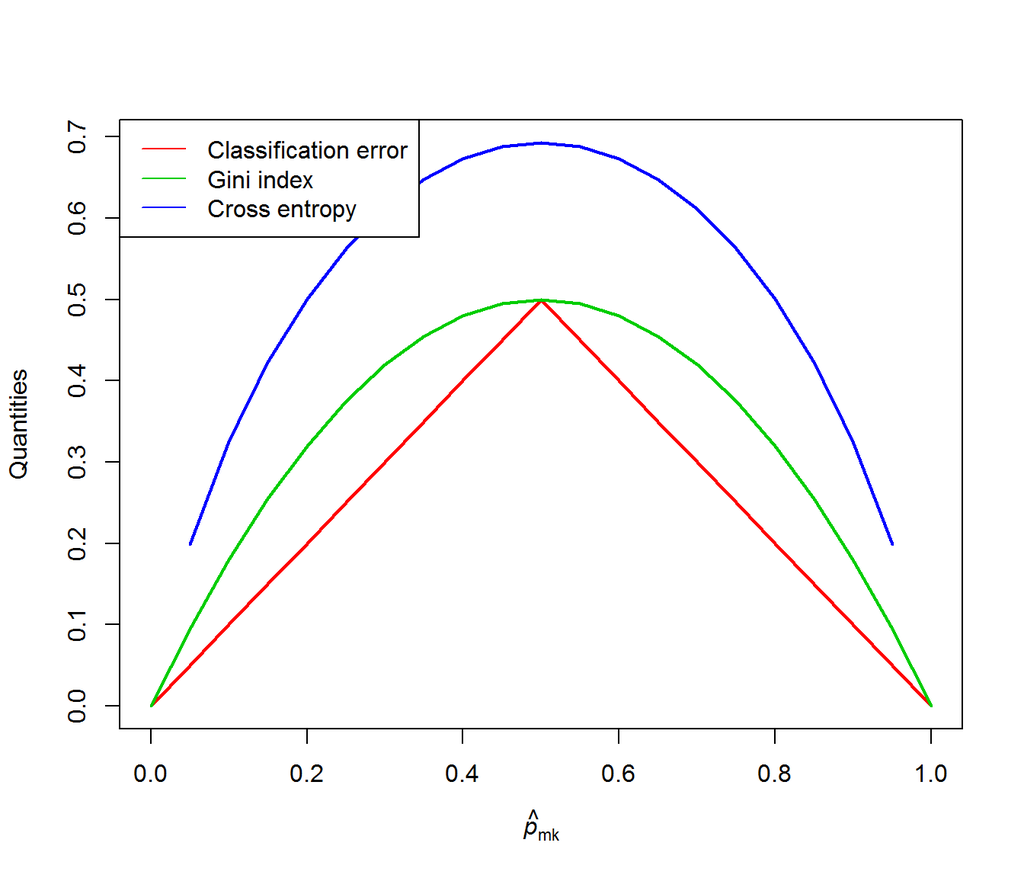

```r
pm1 = seq(0, 1, 0.05)
pm2 = 1 - pm1
clf_error = 1 - apply(cbind(pm1, pm2), 1, max)
g_index = 2*pm1*(1-pm1)
d_entropy = -pm1*log(pm1)-pm2*log(pm2)
matplot(pm1, cbind(clf_error, g_index, d_entropy), col = 2:4, type = "l", lty = 1, lwd = 2, xlab=expression(italic(hat(p))[mk]), ylab = "Quantities", xlim = c(0, 1))
legend("topleft", c("Classification error", "Gini index", "Cross entropy"), col = 2:4, lty = 1)
```

### Excercise 4a

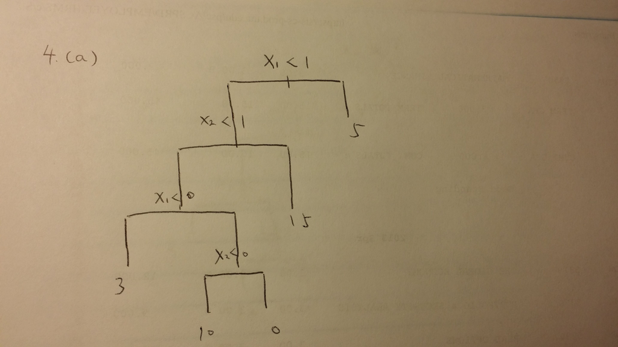

### Excercise 4b

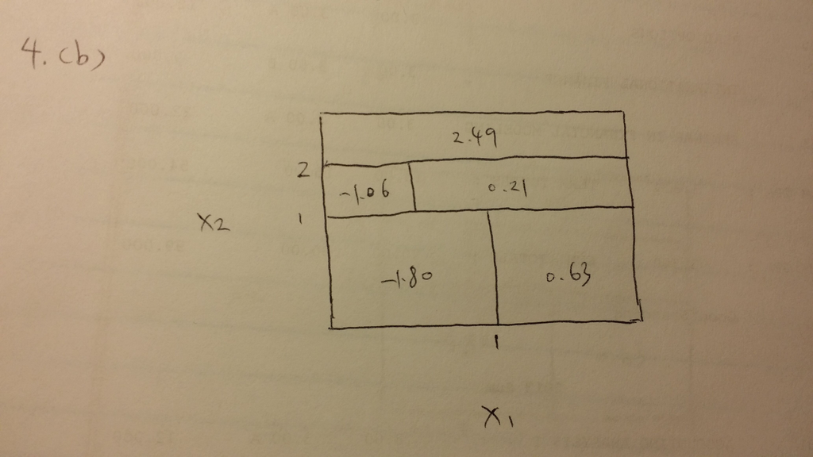

### Excercise 5

For majority voting, ${\hat p_{\rm red}} = \frac{6}{10} = 0.6$, while ${\hat p_{\rm green}} = 0.4$, therefore the classification result is *red*.

For approach based on the average probability: ${\hat p_{\rm red}} = \frac{0.1+0.15+0.2+0.2+0.55+0.6+0.6+0.65+0.7+0.75}{10} = 0.45$ , while ${\hat p_{\rm green}} = 1 - {\hat p_{\rm red}} = 0.55$, therefore the classification result is *green*.

### Excercise 6

The following explanations are taken substantially from ISLR (James, Witten, and Hastie, 2014):  
1. **Grow a large tree**: Take a top-down, greedy approach called recursive binary splitting to split the predictor space where at each step, the best split is made leading to the greatest possible reduction in RSS. Mathmatically, for predictor $X_j$ and cutpoint $s$ such that splitting the predictor space into two regions ${X|X_j < s}$ and ${X|X_j \ge s}$, i.e., for any $j$ and $s$, the pair of half-planes are defined as $R_1(j,s) = {X|X_j < s} {~\rm and~} R_2(j,s) ={X|X_j \ge s}$ therefore, for each split of recursive binary splitting, we are minimizing the equation: ${\sum\limits_{i:x{_i} \in {R_1}(j,s)} {({y_i} - {{\hat y}_{{R_1}}})} ^2} + {\sum\limits_{i:x{_i} \in {R_2}(j,s)} {({y_i} - {{\hat y}_{{R_2}}})} ^2}$ Repeat the process on newly generated regions until a stopping criterion is reached like no region contains more than five observations.  
2. **Prune the tree**: apply cost complexity pruning (aka weakest link pruning) to the large tree in order to obtain a sequence of best subtrees, as a function of $\lambda$: For each value of $\lambda$ we can find a subtree $T \subset T_0$ such that $\sum\limits_{m = 1}^{\left| T \right|} {\sum\limits_{i:{x_i} \in {R_m}} {({y_i} - {{\hat y}_{{R_m}}}) + \alpha \left| T \right|} }$ is as small as possible. $\left| T \right|$ denotes the number of terminal nodes of the tree $T$, $R_m$ is the region corresponds to the terminal node in predictor space, associated with its predicted response ${\hat y}_{R_m}$.  
3. **Use K-fold Cross-validation to choose $\lambda$**: repeat step (1) and (2) on all but the $k$ th fold of the training data while evaluate the mean squared prediction error on the held-out $k$ th fold as a function of $\lambda$. Afterwards, average the results for each $\lambda$ and pick the best $\lambda$ which minimizes the average error.  
4. **Return subtree with best $\lambda$**: Generate and return the subtree with step (2), provided the best $\lambda$.

## Applied

### Excercise 7

```r
library(MASS)
library(randomForest)
```

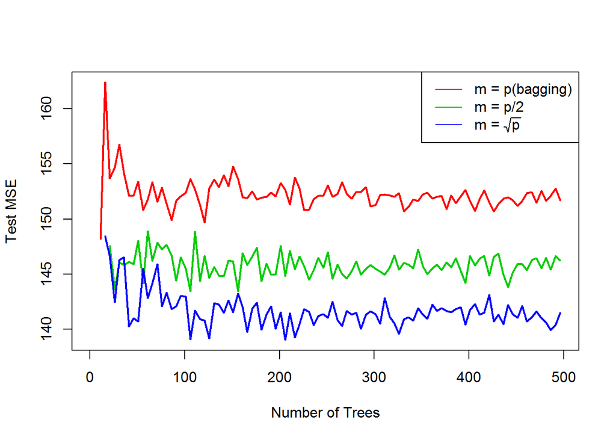

```r
attach(Boston)
set.seed(1)
train = sample(1:nrow(Boston), nrow(Boston)/2)
test.X = Boston[-train, ]
test.Y = medv[-train]
p = ncol(Boston) - 1

ds = c(p, p / 2, sqrt(p))
nts = seq(1, 500, 5)
errors = matrix(NA, length(ds), length(nts))
for ( d_ind in 1:length(ds) ) {
  for ( nt_ind in 1:length(nts)) {
    rf.boston = randomForest(medv~., data = Boston, subset = train, mtry = ds[d_ind], ntree = nts[nt_ind])
    yhat.rf = predict(rf.boston, data = test.X)
    errors[d_ind, nt_ind] = mean((yhat.rf - test.Y)^2)
  }
}
matplot(nts, t(errors), col = 2:4, type = "l", lty = 1, lwd = 2, xlab = "Number of Trees", ylab = "Test MSE")
legend("topright", expression("m = p(bagging)", "m = p/2", "m = "*sqrt(p)), col = 2:4, lty = 1)
```

```r
detach(Boston)
```

The results above indicate that it is more appropriate to use smaller $m$ (number of predictors considered for each split of the tree) for predicting *medv*. After the random forest grows with number of trees larger than 100, the test results become stable.

### Excercise 8a

```r
library(ISLR)
attach(Carseats)
train = sample(1:nrow(Carseats), nrow(Carseats)/2)
test.X = Carseats[-train, ]
test.Y = Sales[-train]
```

### Excercise 8b

```r
tree.carseats = tree(Sales~., data = Carseats, subset = train)
summary(tree.carseats)
```

```
##
## Regression tree:
## tree(formula = Sales ~ ., data = Carseats, subset = train)
## Variables actually used in tree construction:
## [1] "ShelveLoc"   "Price"       "Age"         "CompPrice"   "Advertising"
## [6] "Population"
## Number of terminal nodes:  17
## Residual mean deviance:  1.965 = 359.6 / 183
## Distribution of residuals:
##    Min. 1st Qu.  Median    Mean 3rd Qu.    Max.
## -3.5230 -0.9220 -0.1117  0.0000  0.7836  3.3260
```

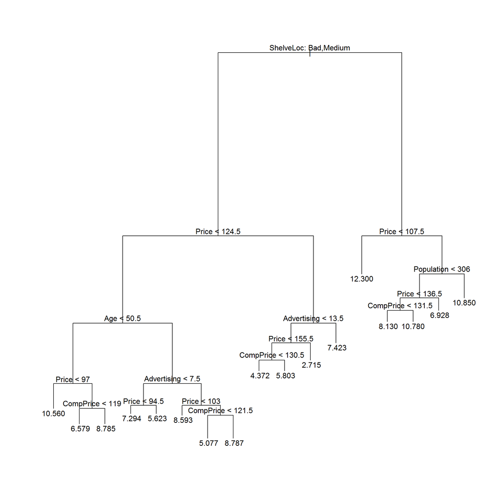

```r
# NOTE: In regression setting, the deviance shown above is simply the sum of squared errors for the tree.
plot(tree.carseats)
text(tree.carseats, pretty = 0)
```

```r
tree.pred = predict(tree.carseats, test.X)
mean((tree.pred - test.Y)^2)
```

```
## [1] 5.13336
```

### Excercise 8c

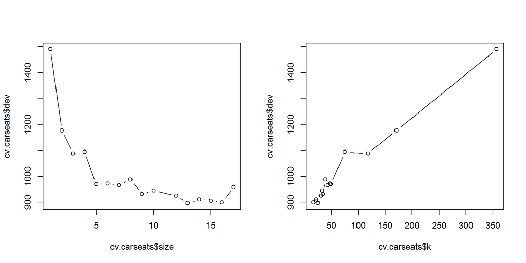

```r
set.seed(1)
cv.carseats = cv.tree(tree.carseats, FUN = prune.tree)
par(mfrow = c(1,2))
plot(cv.carseats$size, cv.carseats$dev, type = "b")
plot(cv.carseats$k, cv.carseats$dev, type = "b")
```

```r
par(mfrow = c(1,1))
cv.carseats$size[which.min(cv.carseats$dev)]
```

```
## [1] 13
```

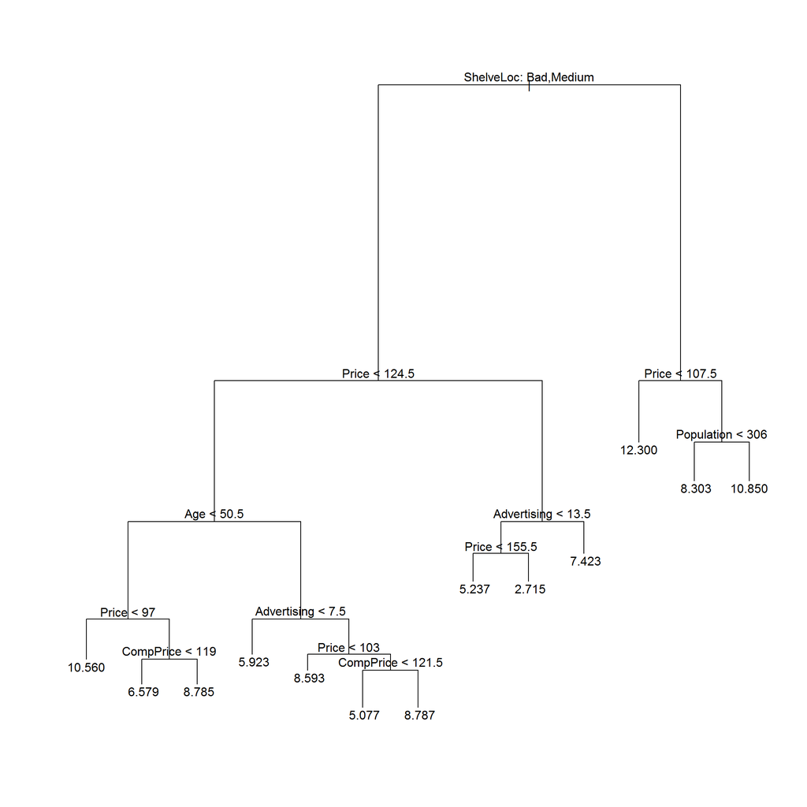

```r
prune.carseats = prune.tree(tree.carseats, best = cv.carseats$size[which.min(cv.carseats$dev)])
plot(prune.carseats)
text(prune.carseats, pretty = 0)
```

```r
tree.pred = predict(prune.carseats, test.X)
mean((tree.pred - test.Y)^2)
```

```
## [1] 5.617099
```

As shown above, pruning the tree **doesn’t** improve the test MSE.

### Excercise 8d

```r
library(randomForest)
bag.carseats = randomForest(Sales~., data = Carseats, subset = train, mtry = ncol(Carseats)-1, ntree = 500)
bag.pred = predict(bag.carseats, test.X)
mean((bag.pred - test.Y)^2)
```

```
## [1] 3.088662
```

```r
importance(bag.carseats)
```

```
##             IncNodePurity
## CompPrice       123.97922
## Income           67.22459
## Advertising     108.14413
## Population       81.46342
## Price           445.46236
## ShelveLoc       403.36534
## Age             148.68433
## Education        39.60842
## Urban            10.17719
## US                9.82959
```

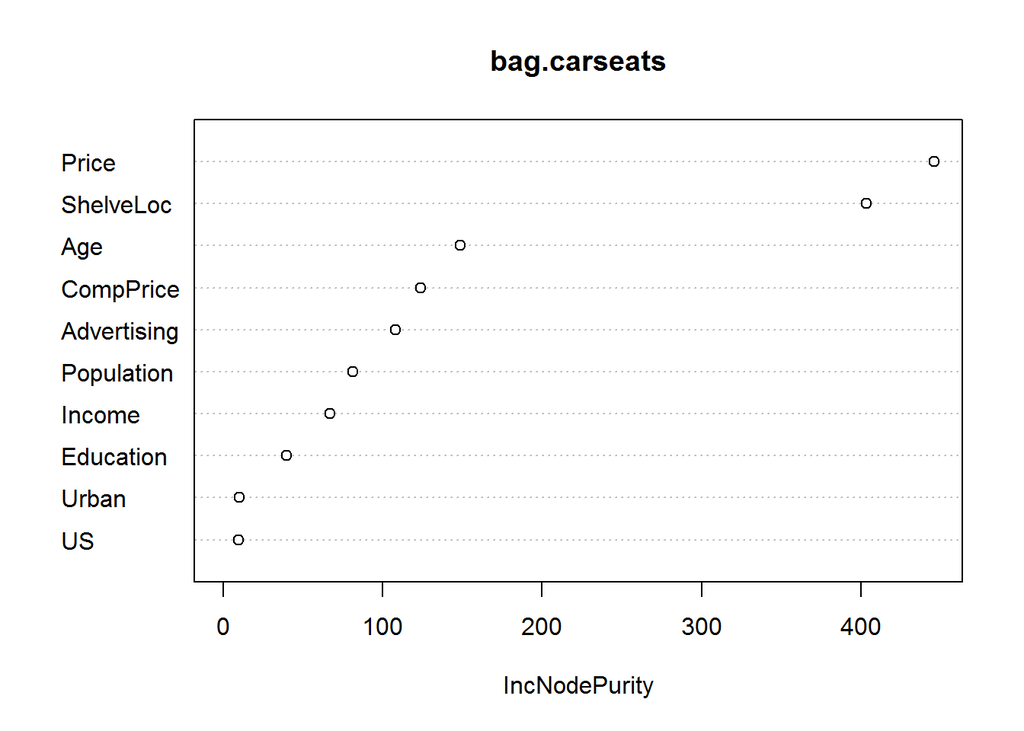

```r
varImpPlot(bag.carseats)
```

### Excercise 8e

```r
rf.carseats = randomForest(Sales~., data = Carseats, subset = train, mtry = sqrt(ncol(Carseats)-1), ntree = 500)
rf.pred = predict(rf.carseats, test.X)
mean((rf.pred - test.Y)^2)
```

```
## [1] 3.323668
```

The test MSE for **bagging** is lowest among the four models (regression tree, pruned regression tree, bagging and random forest) evaluated so far.

```r
importance(rf.carseats)
```

```
##             IncNodePurity
## CompPrice       122.52759
## Income           98.28385
## Advertising     119.96414
## Population      106.50432
## Price           355.63749
## ShelveLoc       310.66427
## Age             147.55011
## Education        61.04585
## Urban            12.80297
## US               34.07924
```

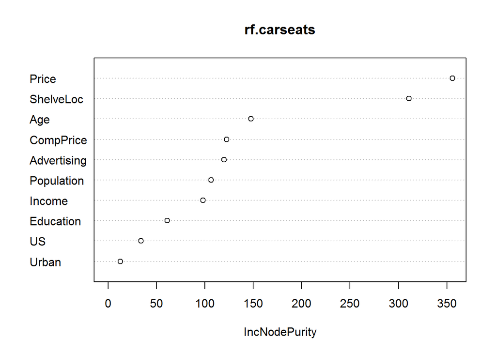

```r
varImpPlot(rf.carseats)
```

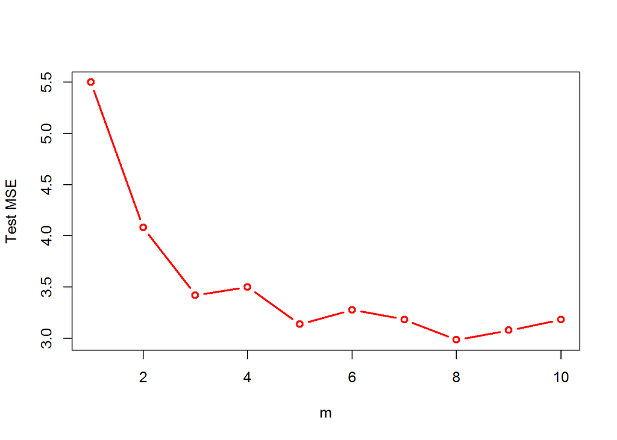

```r
p = ncol(Carseats) - 1
errors = c()
for ( d in seq(1, p) ) {
  rf.carseats = randomForest(Sales~., data = Carseats, subset = train, mtry = d, ntree = 50)
  rf.pred = predict(rf.carseats, test.X)
  errors[d] = mean((rf.pred - test.Y)^2)
}
plot(errors, col = "red", type = "b", lwd = 2, xlab = "m", ylab = "Test MSE")
```

```r
which.min(errors)
```

```
## [1] 8
```

```r
detach(Carseats)
```

As shown above, when $m = 8$, the test MSE is lowest (given number of trees $B = 50$, which is sufficiently large in our case for the error rate to have settled down). Besides, the error rate is only slight different after $m = 5$.

### Excercise 9a

```r
attach(OJ)
set.seed(1)
train = sample(1:nrow(OJ), 800)
test.X = OJ[-train, ]
test.Y = Purchase[-train]
```

### Excercise 9b

```r
tree.oj = tree(Purchase~., data = OJ, subset = train)
summary(tree.oj)
```

```
##
## Classification tree:
## tree(formula = Purchase ~ ., data = OJ, subset = train)
## Variables actually used in tree construction:
## [1] "LoyalCH"       "PriceDiff"     "SpecialCH"     "ListPriceDiff"
## Number of terminal nodes:  8
## Residual mean deviance:  0.7305 = 578.6 / 792
## Misclassification error rate: 0.165 = 132 / 800
```

Four variables–LoyalCH, PriceDiff, SpecialCH, ListPriceDiff have been selected to effectively form the tree.

Within the training set, 132 out of 800 examples are misclassified, namely the training error rate is 16.50%. Besides, there are 8 number of terminal nodes in the generated tree.

### Excercise 9c

```r
tree.oj
```

```
## node), split, n, deviance, yval, (yprob)
##       * denotes terminal node
##
##  1) root 800 1064.00 CH ( 0.61750 0.38250 )
##    2) LoyalCH < 0.508643 350  409.30 MM ( 0.27143 0.72857 )
##      4) LoyalCH < 0.264232 166  122.10 MM ( 0.12048 0.87952 )
##        8) LoyalCH < 0.0356415 57   10.07 MM ( 0.01754 0.98246 ) *
##        9) LoyalCH > 0.0356415 109  100.90 MM ( 0.17431 0.82569 ) *
##      5) LoyalCH > 0.264232 184  248.80 MM ( 0.40761 0.59239 )
##       10) PriceDiff < 0.195 83   91.66 MM ( 0.24096 0.75904 )
##         20) SpecialCH < 0.5 70   60.89 MM ( 0.15714 0.84286 ) *
##         21) SpecialCH > 0.5 13   16.05 CH ( 0.69231 0.30769 ) *
##       11) PriceDiff > 0.195 101  139.20 CH ( 0.54455 0.45545 ) *
##    3) LoyalCH > 0.508643 450  318.10 CH ( 0.88667 0.11333 )
##      6) LoyalCH < 0.764572 172  188.90 CH ( 0.76163 0.23837 )
##       12) ListPriceDiff < 0.235 70   95.61 CH ( 0.57143 0.42857 ) *
##       13) ListPriceDiff > 0.235 102   69.76 CH ( 0.89216 0.10784 ) *
##      7) LoyalCH > 0.764572 278   86.14 CH ( 0.96403 0.03597 ) *
```

### Excercise 9d

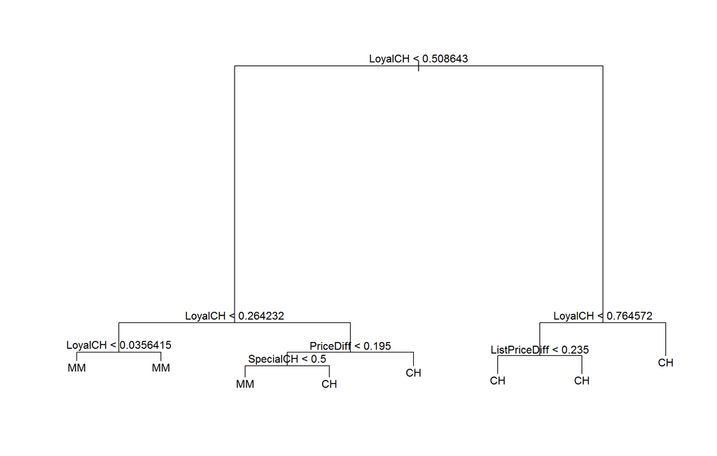

```r
plot(tree.oj)
text(tree.oj, pretty = 0)
```

### Excercise 9e

```r
tree.pred = predict(tree.oj, test.X, type = "class")
table(tree.pred, test.Y)
```

```
##          test.Y
## tree.pred  CH  MM
##        CH 147  49
##        MM  12  62
```

```r
mean(tree.pred != test.Y)
```

```
## [1] 0.2259259
```

The test error rate is 22.59%.

### Excercise 9f

```r
set.seed(3)
cv.oj = cv.tree(tree.oj, FUN = prune.misclass)
cv.oj
```

```
## $size
## [1] 8 5 2 1
##
## $dev
## [1] 151 151 157 306
##
## $k
## [1]       -Inf   0.000000   4.666667 160.000000
##
## $method
## [1] "misclass"
##
## attr(,"class")
## [1] "prune"         "tree.sequence"
```

### Excercise 9g

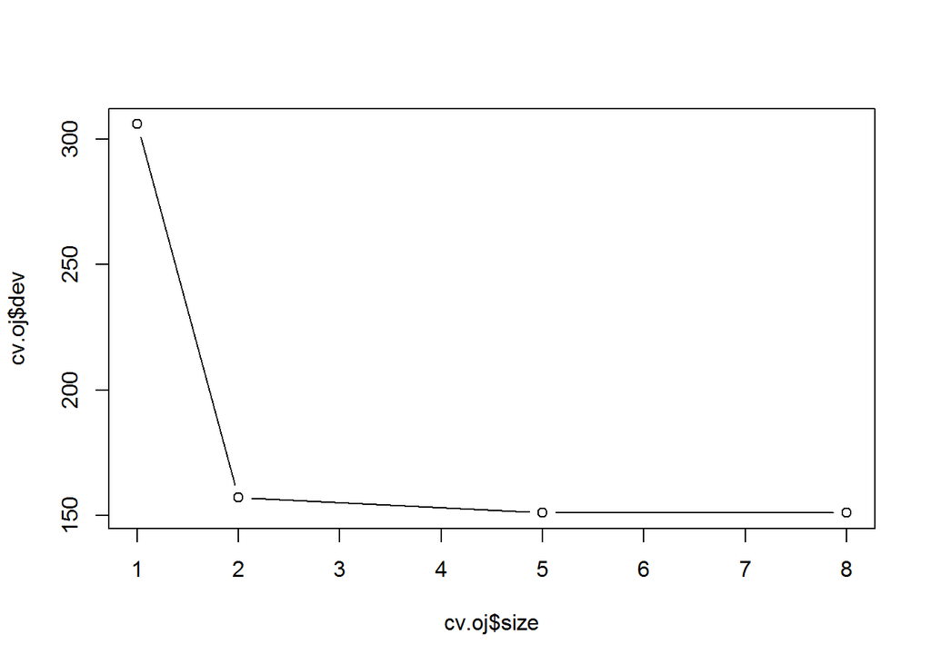

```r
plot(cv.oj$size, cv.oj$dev, type = "b")
```

### Excercise 9h

Tree sizes of 8, 5 have the same, lowest cross-validated classification error rate. Hence, we prefer tree size of 5 that has lower variance.

### Excercise 9i

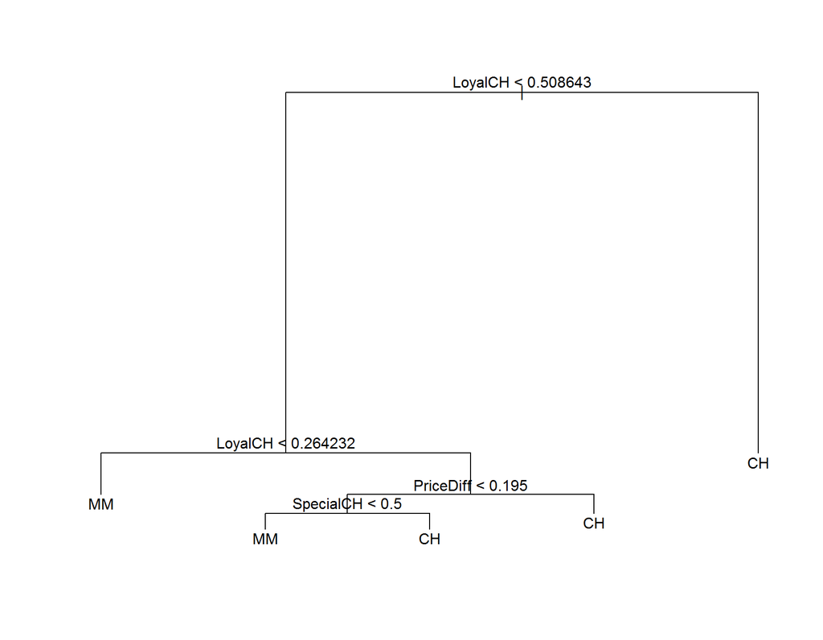

```r
prune.oj = prune.misclass(tree.oj, best = 5)
plot(prune.oj)
text(prune.oj, pretty = 0)
```

### Excercise 9j

```r
summary(prune.oj)$misclass
```

```
## [1] 132 800
```

Training error rate for unpruned tree is 16.50% while for pruned tree it is also 16.50%. Both are the same.

### Excercise 9k

```r
tree.pred = predict(prune.oj, test.X, type = "class")
table(tree.pred, test.Y)
```

```
##          test.Y
## tree.pred  CH  MM
##        CH 147  49
##        MM  12  62
```

```r
mean(tree.pred != test.Y)
```

```
## [1] 0.2259259
```

```r
detach(OJ)
```

Test error rate for unpruned tree is 22.59% while for pruned tree it is also 22.59%. Both are the same.

### Excercise 10a

```r
library(gbm)
Hitters = Hitters[!is.na(Hitters$Salary), ]
Hitters$LogSalary = log(Hitters$Salary)
Hitters = subset(Hitters, select = -Salary)
attach(Hitters)
```

### Excercise 10b

```r
set.seed(1)
train = sample(1:nrow(Hitters), 200)
test.X = Hitters[-train, ]
test.Y = LogSalary[-train]
```

### Excercise 10c

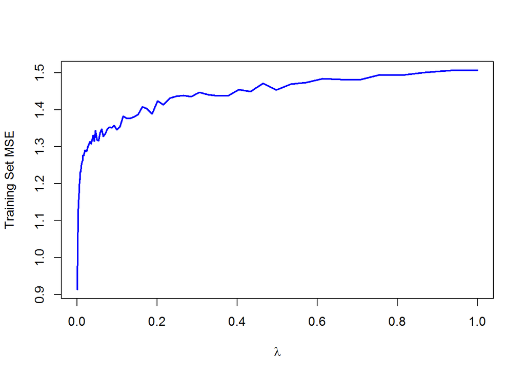

```r
grid = 10^seq(-3, 0, length.out = 100)
train_errors = c(); test_errors = c()
ind = 1
for ( lambda in grid ) {
  boost.hitters = gbm(LogSalary~., data = Hitters[train, ], distribution = "gaussian", n.trees = 1000, shrinkage = lambda, interaction.depth = 1)
  yhat.boost = predict(boost.hitters, n.trees = 1000)
  train_errors[ind] = mean((yhat.boost - LogSalary)^2)
  yhat.boost = predict(boost.hitters, newdata = test.X, n.trees = 1000)
  test_errors[ind] = mean((yhat.boost - test.Y)^2)
  ind = ind + 1
}
plot(grid, train_errors, type = "l", lwd = 2, col = "blue", xlab = expression(symbol("\154")), ylab = "Training Set MSE")
```

### Excercise 10d

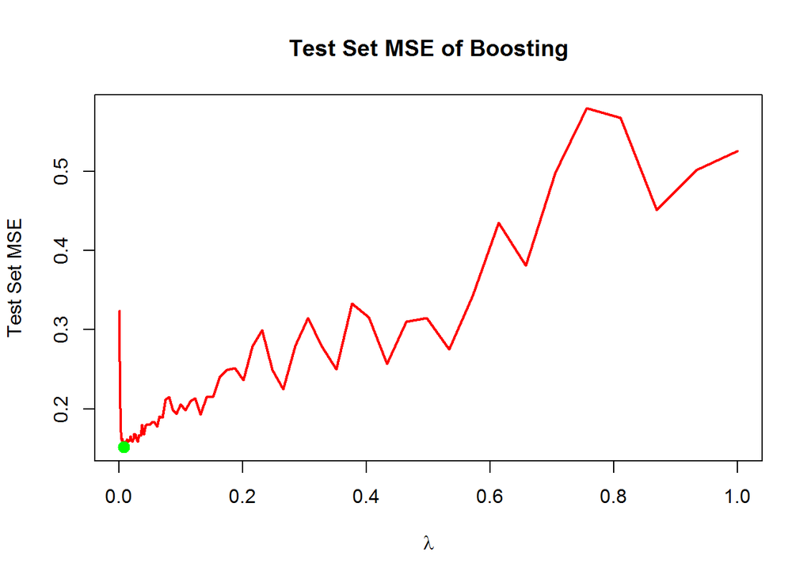

```r
plot(grid, test_errors, type = "l", lwd = 2, col = "red", xlab = expression(symbol("\154")), ylab = "Test Set MSE")
title("Test Set MSE of Boosting")
points(grid[which.min(test_errors)], min(test_errors), col = "green",cex = 2, pch = 20)
```

Best $\lambda$ is chosen as: 0.0081113, where the corresponding test set MSE is 0.15.

### Excercise 10e

Comparing to the multiple linear regression:

```r
lm.fit = lm(LogSalary~., data = Hitters[train,])
lm.pred = predict(lm.fit, newdata = test.X)
mean((lm.pred - test.Y)^2)
```

```
## [1] 0.3938666
```

When chosen with best $\lambda$, boosting greatly outperforms linear regression.

Comparing to best subset method:

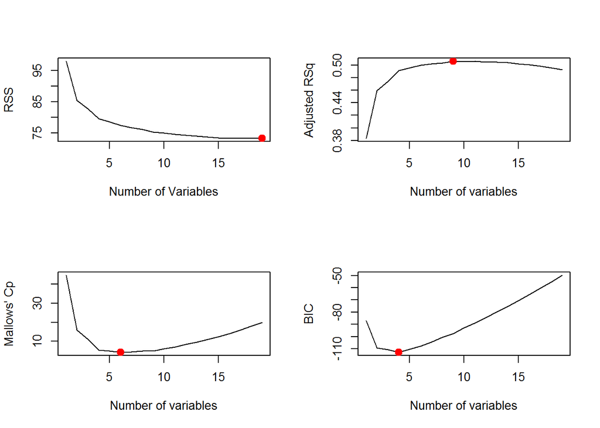

```r
library(leaps)
regfit.full = regsubsets(LogSalary~., data = Hitters[train, ], nvmax = ncol(Hitters)-1)
reg.summary = summary(regfit.full)
par(mfrow = c(2,2))
plot(reg.summary$rss, xlab = "Number of Variables", ylab = "RSS", type = "l")
points(which.min(reg.summary$rss), min(reg.summary$rss), col = "red", cex = 2, pch = 20)
plot(reg.summary$adjr2, xlab = "Number of variables", ylab = "Adjusted RSq", type = "l")
points(which.max(reg.summary$adjr2), max(reg.summary$adjr2), col = "red", cex = 2, pch = 20)
plot(reg.summary$cp, xlab = "Number of variables", ylab = "Mallows' Cp", type = "l")
points(which.min(reg.summary$cp), min(reg.summary$cp), col = "red", cex = 2, pch = 20)
plot(reg.summary$bic, xlab = "Number of variables", ylab = "BIC", type = "l")
points(which.min(reg.summary$bic), min(reg.summary$bic), col = "red", cex = 2, pch = 20)
```

Choosing the best combination based on Mallows’ Cp, then we will have 6 number of variables to fit the data. They are:

```r
coef(regfit.full, which.min(reg.summary$cp))
```

```
##   (Intercept)          Runs         Walks         CHits        CWalks
##  4.8358971239  0.0049119424  0.0095924017  0.0010204524 -0.0008660235
##       LeagueN     DivisionW
##  0.1840871860 -0.2608419300
```

Refit the training set with the coefficients obtained from best subset method, we have:

```r
lm.fit = lm(LogSalary~Runs+Walks+CHits+CWalks+League+Division, data = Hitters[train,])
lm.pred = predict(lm.fit, newdata = test.X)
mean((lm.pred - test.Y)^2)
```

```
## [1] 0.4065098
```

```r
par(mfrow = c(1,1))
```

, which is inferior to the boosting (its test set MSE is even higher than the multiple linear regression using full set of features).

**Therefore, we can say that boosting performs much better in this case than linear squares method at the cost of interpretability**.

### Excercise 10f

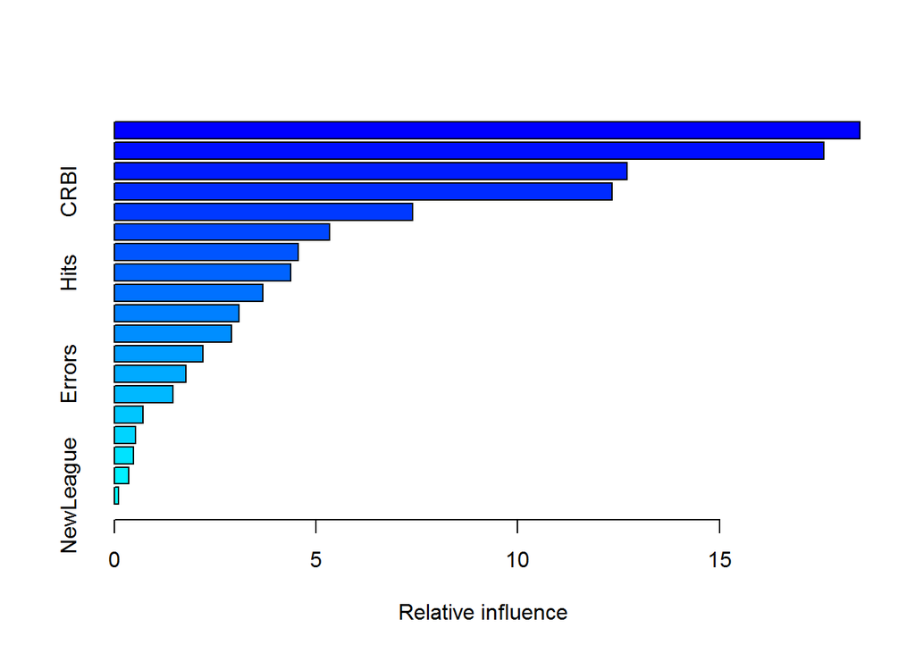

```
##                 var    rel.inf
## CAtBat       CAtBat 18.4773839
## CHits         CHits 17.5805545
## CRuns         CRuns 12.7090594
## CRBI           CRBI 12.3433535
## CWalks       CWalks  7.3860338
## Walks         Walks  5.3280161
## Years         Years  4.5512552
## Hits           Hits  4.3728005
## CHmRun       CHmRun  3.6743299
## PutOuts     PutOuts  3.0854070
## RBI             RBI  2.9105415
## HmRun         HmRun  2.1988447
## Errors       Errors  1.7746892
## Division   Division  1.4458970
## League       League  0.7052709
## AtBat         AtBat  0.5201532
## Runs           Runs  0.4802011
## Assists     Assists  0.3547611
## NewLeague NewLeague  0.1014475
```

```r
boost.hitters = gbm(LogSalary~., data = Hitters[train, ], distribution = "gaussian", n.trees = 1000, shrinkage = grid[which.min(test_errors)], interaction.depth = 1)
summary(boost.hitters)
```

### Excercise 10g

```r
bag.hitters = randomForest(LogSalary~., data = Hitters, subset = train, mtry = ncol(Hitters)-1, ntree = 500)
bag.pred = predict(bag.hitters, test.X)
mean((bag.pred - test.Y)^2)
```

```
## [1] 0.1200481
```

```r
detach(Hitters)
```

As shown above, the test set MSE of *Bagging* is lower than the one of *Boosting*.

### Excercise 11a

```r
attach(Caravan)
set.seed(1)
train = sample(1:nrow(Caravan), 1000)
test.X = Caravan[-train, ]
test.Y = Purchase[-train]
```

### Excercise 11b

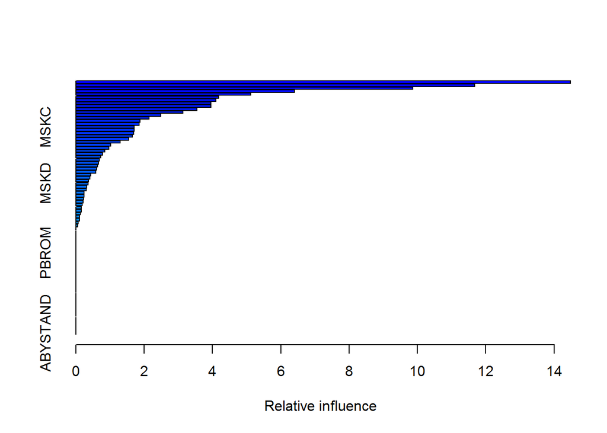

```
##               var     rel.inf
## APERSAUT APERSAUT 14.47891453
## MOSTYPE   MOSTYPE 11.67945236
## PPERSAUT PPERSAUT  9.86351348
## MBERMIDD MBERMIDD  6.39664455
## MINKGEM   MINKGEM  5.11221418
## PWAPART   PWAPART  4.18623656
## MRELGE     MRELGE  4.09923210
## MOPLHOOG MOPLHOOG  3.96017282
## PBRAND     PBRAND  3.95791519
## MINK7512 MINK7512  3.54423475
## MGODOV     MGODOV  3.13385028
## MFGEKIND MFGEKIND  2.48589511
## MINK3045 MINK3045  2.13763800
## MBERARBO MBERARBO  1.87303555
## MOPLMIDD MOPLMIDD  1.85189210
## MSKC         MSKC  1.71017124
## MBERZELF MBERZELF  1.70642727
## ALEVEN     ALEVEN  1.68973123
## MOSHOOFD MOSHOOFD  1.65005120
## MBERARBG MBERARBG  1.55143366
## MAUT1       MAUT1  1.29225099
## MGODPR     MGODPR  1.02285807
## MINK4575 MINK4575  0.97313922
## MOPLLAAG MOPLLAAG  0.84318156
## MGODGE     MGODGE  0.77808802
## MINKM30   MINKM30  0.72243606
## MSKB1       MSKB1  0.69270307
## MSKA         MSKA  0.66224962
## MAUT0       MAUT0  0.64168277
## MHKOOP     MHKOOP  0.61400288
## MGODRK     MGODRK  0.58063947
## MZPART     MZPART  0.43577038
## MFALLEEN MFALLEEN  0.41580521
## MZFONDS   MZFONDS  0.37653290
## MSKD         MSKD  0.35465923
## MBERHOOG MBERHOOG  0.32174852
## MHHUUR     MHHUUR  0.30757494
## MAUT2       MAUT2  0.24526990
## MGEMOMV   MGEMOMV  0.24296452
```

[output cut: 31 more lines]

```
## AMOTSCO   AMOTSCO  0.00000000
## AVRAAUT   AVRAAUT  0.00000000
## AAANHANG AAANHANG  0.00000000
## ATRACTOR ATRACTOR  0.00000000
## AWERKT     AWERKT  0.00000000
## ABROM       ABROM  0.00000000
## APERSONG APERSONG  0.00000000
## AGEZONG   AGEZONG  0.00000000
## AWAOREG   AWAOREG  0.00000000
## ABRAND     ABRAND  0.00000000
## AZEILPL   AZEILPL  0.00000000
## APLEZIER APLEZIER  0.00000000
## AFIETS     AFIETS  0.00000000
## AINBOED   AINBOED  0.00000000
## ABYSTAND ABYSTAND  0.00000000
```

```r
library(gbm)
tmpCaravan = Caravan
transformedPurchase = rep(0, length(Purchase))
transformedPurchase[Purchase == "Yes"] = 1
tmpCaravan = cbind(tmpCaravan, transformedPurchase)
tmpCaravan = subset(tmpCaravan, select = -Purchase)
boost.caravan = gbm(transformedPurchase~., data = tmpCaravan[train, ], distribution = "bernoulli", n.trees = 1000, shrinkage = 0.01, interaction.depth = 1)
summary(boost.caravan)
```

### Excercise 11c

Using boosting:

```r
boost.prob = predict(boost.caravan, newdata = tmpCaravan[-train, ], n.trees = 1000, type = "response")
boost.pred = rep("No", length(boost.prob))
boost.pred[boost.prob > 0.20] = "Yes"
table(boost.pred, test.Y)
```

```
##           test.Y
## boost.pred   No  Yes
##        No  4381  268
##        Yes  146   27
```

```r
mean(boost.pred == test.Y)
```

```
## [1] 0.9141435
```

Using logistic regression:

```r
glm.fit = glm(Purchase~., data = Caravan[train, ], family = binomial)
glm.probs = predict(glm.fit, newdata = test.X, type = "response")
glm.pred = rep("No", length(glm.probs))
glm.pred[glm.probs > 0.20] = "Yes"
table(glm.pred, test.Y)
```

```
##         test.Y
## glm.pred   No  Yes
##      No  4244  257
##      Yes  283   38
```

Using KNN:

```r
library(class) # for KNN function
train.Y = Purchase[train]
knn.pred = knn(as.matrix(subset(Caravan, select = -Purchase)[train, ]), as.matrix(subset(Caravan, select = -Purchase)[-train, ]), train.Y, k = 1)
table(knn.pred, test.Y)
```

```
##         test.Y
## knn.pred   No  Yes
##      No  4294  275
##      Yes  233   20
```

```r
mean(knn.pred == test.Y)
```

```
## [1] 0.8946495
```

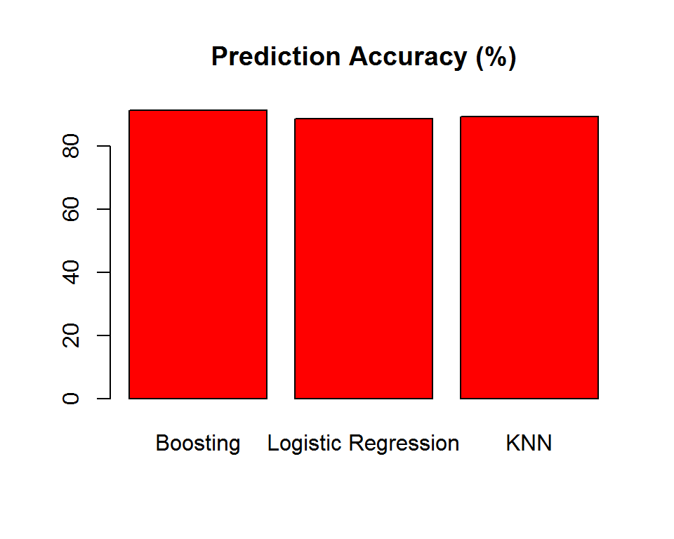

```r
barplot(c(mean(boost.pred == test.Y)*100, mean(glm.pred == test.Y)*100, mean(knn.pred == test.Y)*100), col = "red", names.arg = c("Boosting", "Logistic Regression", "KNN"), main = "Prediction Accuracy (%)")
```

```r
detach(Caravan)
```

Among three methods, **Boosting** performs best in predicting whether people will make a purchase.

### Excercise 12

In this excercise, we will work on the dataset `Auto`.

```r
library(leaps)
library(gam)
Auto = subset(Auto, select = -name) # it has been verified that name is not statistically significant for prediction task.
attach(Auto)
set.seed(1)
train = sample(1:nrow(Auto), nrow(Auto)/2)
test.X = Auto[-train, ]
test.Y = mpg[-train]
```

Using boosting:

```r
boost.auto = gbm(mpg~., data = Auto, distribution = "gaussian", n.trees = 2000, shrinkage = 0.001, interaction.depth = 1)
boost.pred = predict(boost.auto, newdata = test.X, n.trees = 2000)
mean((boost.pred - test.Y)^2)
```

```
## [1] 13.9561
```

, the test set MSE is 13.96

Using bagging:

```r
bag.auto = randomForest(mpg~., data = Auto, subset = train, mtry = ncol(Auto)-1, ntree = 500)
bag.pred = predict(bag.auto, test.X)
mean((bag.pred - test.Y)^2)
```

```
## [1] 7.68704
```

, the test set MSE is 7.69.

Using random forest:

```r
rf.auto = randomForest(mpg~., data = Auto, subset = train, mtry = sqrt(ncol(Auto)-1), ntree = 500)
rf.pred = predict(rf.auto, test.X)
mean((rf.pred - test.Y)^2)
```

```
## [1] 7.643824
```

, the test set MSE is 7.64.

Using linear regression with coefficients obtained from best subset method:

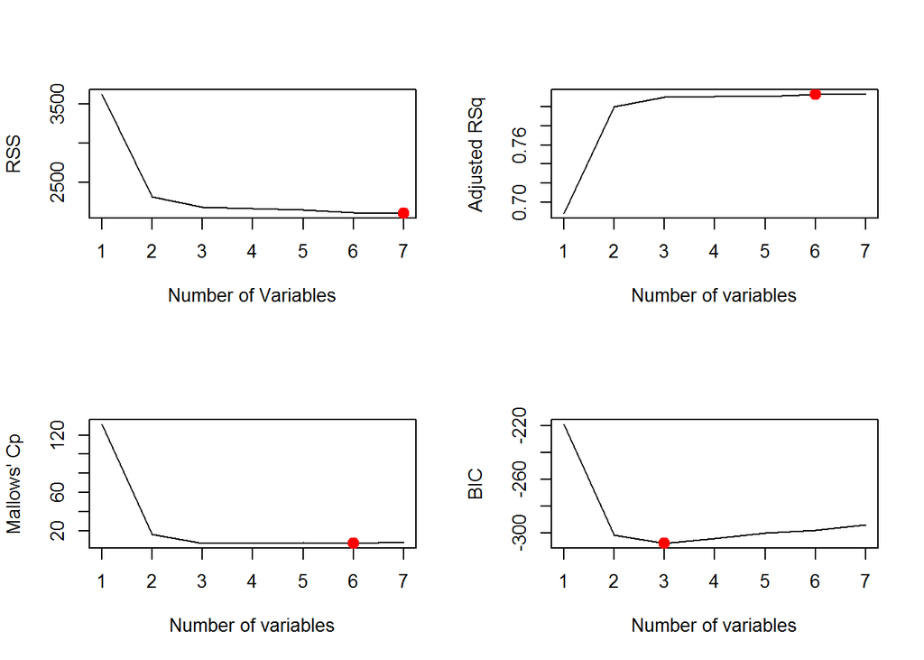

```r
regfit.full = regsubsets(mpg~., data = Auto[train, ], nvmax = ncol(Auto)-1)
reg.summary = summary(regfit.full)
par(mfrow = c(2,2))
plot(reg.summary$rss, xlab = "Number of Variables", ylab = "RSS", type = "l")
points(which.min(reg.summary$rss), min(reg.summary$rss), col = "red", cex = 2, pch = 20)
plot(reg.summary$adjr2, xlab = "Number of variables", ylab = "Adjusted RSq", type = "l")
points(which.max(reg.summary$adjr2), max(reg.summary$adjr2), col = "red", cex = 2, pch = 20)
plot(reg.summary$cp, xlab = "Number of variables", ylab = "Mallows' Cp", type = "l")
points(which.min(reg.summary$cp), min(reg.summary$cp), col = "red", cex = 2, pch = 20)
plot(reg.summary$bic, xlab = "Number of variables", ylab = "BIC", type = "l")
points(which.min(reg.summary$bic), min(reg.summary$bic), col = "red", cex = 2, pch = 20)
```

By choosing the best combination based on Mallows’ Cp, we will have 6 number of variables to fit the data. They are:

```r
coef(regfit.full, which.min(reg.summary$cp))
```

```
##   (Intercept)     cylinders  displacement    horsepower        weight
## -16.324046261  -0.846528310   0.021733734  -0.027717891  -0.005454913
##          year        origin
##   0.746315106   1.601357872
```

```r
lm.fit = lm(mpg ~ cylinders + displacement + weight + year + origin , data = Auto[train,])
lm.pred = predict(lm.fit, newdata = test.X)
mean((lm.pred - test.Y)^2)
```

```
## [1] 11.18604
```

```r
par(mfrow = c(1,1))
```

, the test set MSE is 11.19.

Using generalized additive method with smoothing splines:

```r
gam.fit = gam(mpg ~ year + origin + cylinders + s(acceleration, 5) + s(displacement, 5) + s(weight, 5) + s(horsepower, 5), data = Auto, subset = train)
gam.pred = predict(gam.fit, newdata = test.X)
mean((gam.pred - test.Y)^2)
```

```
## [1] 9.491843
```

, the test set MSE is 9.49.

Finally, we can compare the results obtained from all five methods:

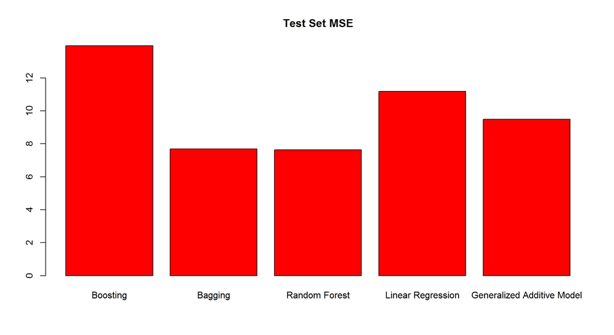

```r
barplot(c(mean((boost.pred - test.Y)^2), mean((bag.pred - test.Y)^2), mean((rf.pred - test.Y)^2), mean((lm.pred - test.Y)^2), mean((gam.pred - test.Y)^2)), col = "red", names.arg = c("Boosting", "Bagging", "Random Forest", "Linear Regression", "Generalized Additive Model"), main = "Test Set MSE")
```

Above plot shows that **random forest** performs **best** among all the five methods evaluated.

Explanation: For `Auto` dataset, boosting is inferior to others due to $p$ is very small for which it didn’t benefit from its *learning slowly* nature. GAM (with smoothing splines on predictors *acceleration*, *displacement*, *weight* and *horsepower*) performs better because it captures the true relationship between the predictors and response (see Excercise 8, Ch7) while the linear regression failed to do so. Approaches like bagging and random forest are superior to GAM due to that they split the predictor space (where the interaction effects occur among 4 out of 7 predictors) into regions in such way that minimicing the non-linear data as well as interactions among the predictors.

# References

[JWH14] G. James, D. Witten and T. Hastie. *An Introduction to Statistical Learning: With Applications in R.* 2014.